# NYC Council Data Science Test - ANALYSIS

##### Trend Analysis

Regarding the trend, one could say that it is **moving from increasing to decreasing trend from 2011 with seasonality**.

NOTE: The trend is based on the difference in the monthly mean arrest between the two regions across the year.

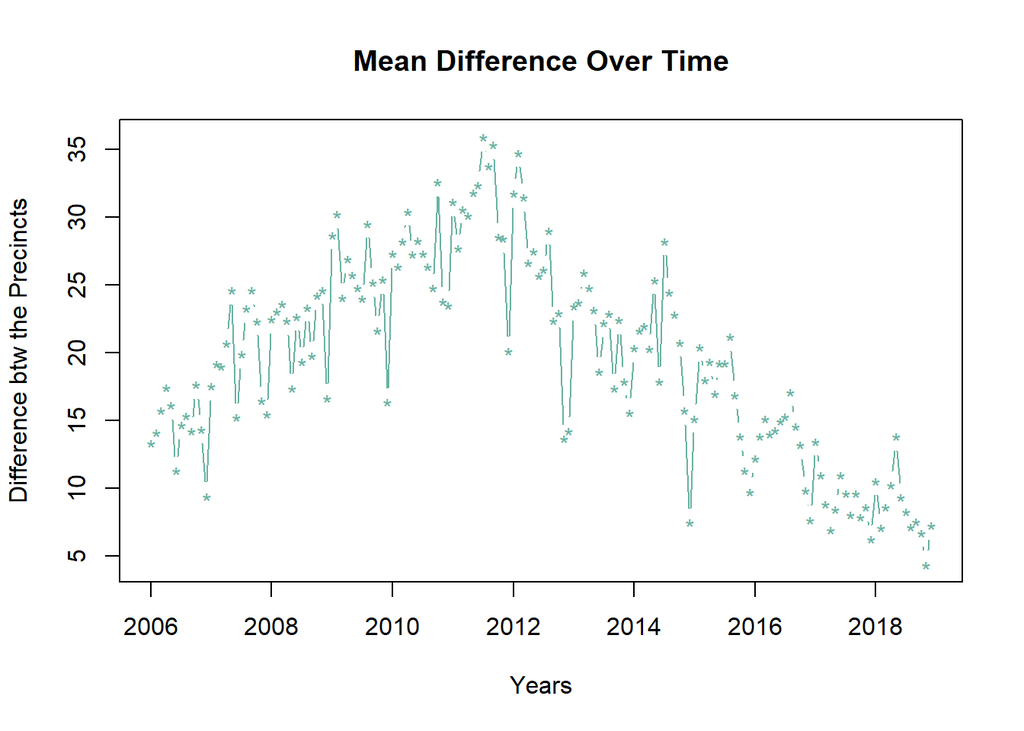

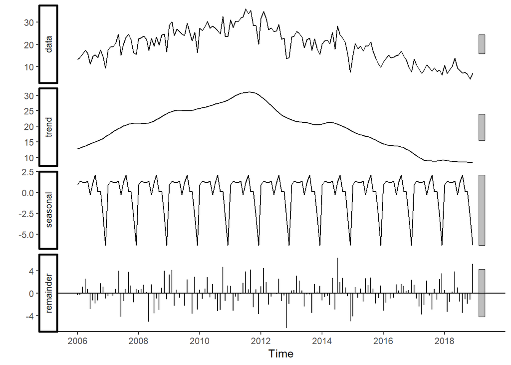

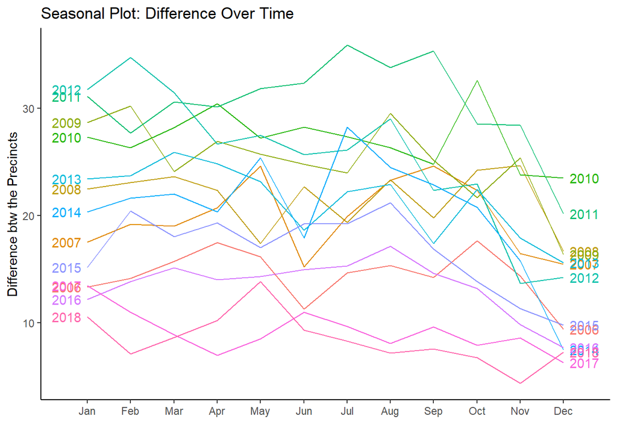

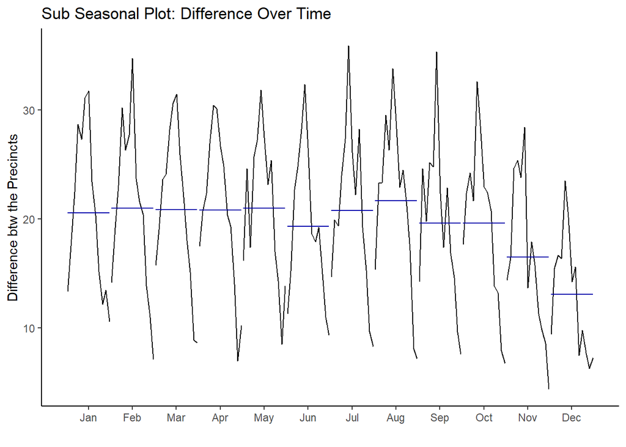

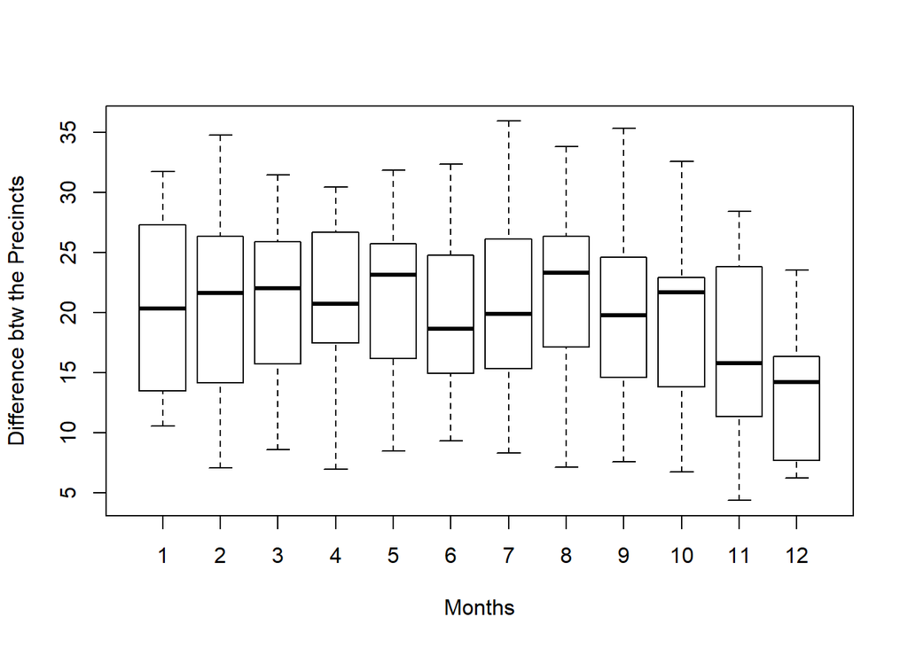

##### Answer

Precinct 73 has a **greater average amount of crime** than precinct 19 across the time on average. Yet, to answer this question, one should be careful since the analysis disregard the demographic difference between the two communities. To confirm, I ran a linear regression.

Based on the P-val of the precinct, one could say that the **location** does **not** have a statistical impact on the mean of crime controlling the year fixed. In contrast, the year has a statistical impact on the monthly mean number of arrests.

Regarding the trend, one could say that it is **moving from increasing to decreasing trend from 2011 with seasonality**. This happens mostly because the crime rates in precinct 73 are decreasing. For instance, after reaching the peak rate, 43.87%, in 2011-07, it gradually decreases. And, the rate remains around 13% since 2018-08.

*Further research on the characteristics of each neighborhood such as ethnicity, environment, economic status, and such could help one to have a better understanding of the crime rates.*

```
FALSE
FALSE Call:
FALSE lm(formula = formula3, data = q3.dat)
FALSE
FALSE Residuals:
FALSE     Min      1Q  Median      3Q     Max
FALSE -7.6214 -2.8034 -0.1228  2.6316  7.1568
FALSE
FALSE Coefficients:
FALSE                     Estimate Std. Error t value Pr(>|t|)
FALSE (Intercept)        1.458e+03  1.884e+01  77.424   <2e-16 ***
FALSE yr                -7.156e-01  9.362e-03 -76.443   <2e-16 ***
FALSE arrest_precinct73 -5.429e-03  7.006e-02  -0.077    0.938
FALSE ---
FALSE Signif. codes:  0 '***' 0.001 '**' 0.01 '*' 0.05 '.' 0.1 ' ' 1
FALSE
FALSE Residual standard error: 3.409 on 9469 degrees of freedom
FALSE Multiple R-squared:  0.3816,  Adjusted R-squared:  0.3815
FALSE F-statistic:  2922 on 2 and 9469 DF,  p-value: < 2.2e-16
```

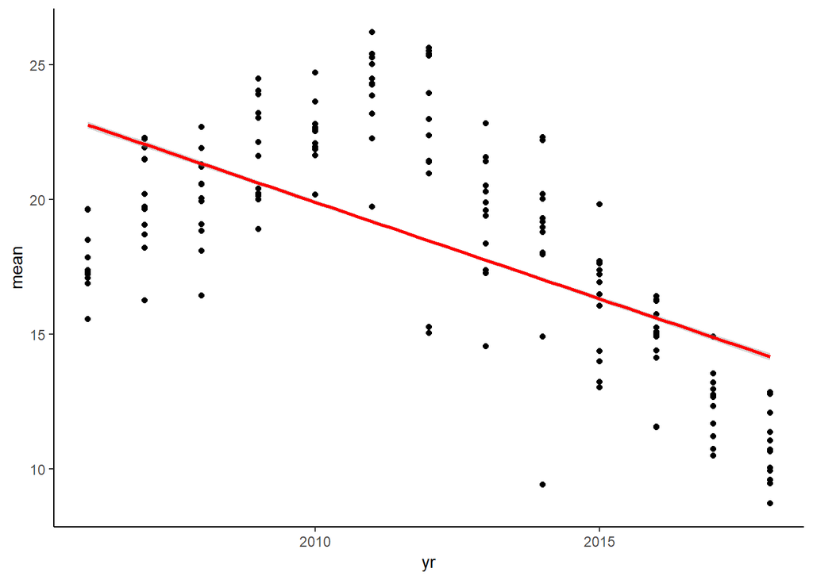

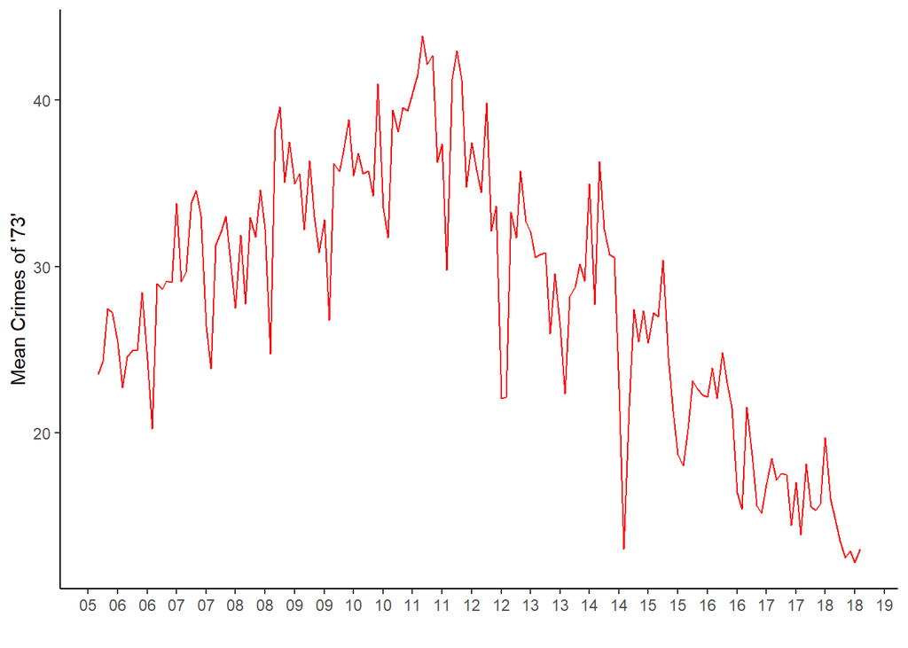

#### **4. What model would you build to predict crime to better allocate NYPD resources? What challenges do you foresee? What variables would be included? How would you evaluate the model? Discuss in no more than 150 words.**

##### Validation

As a stationary check, I ran the Dickey-Fuller Test (adf.test), Kwiatkowski-Phillips-Schmidt-Shin (kpss.test), and the Ljung-Box test(Box.test). According to the p-values of `Box.test` and `kpss.test`, it is a random walk; however, `adf.test` says otherwise: the data is stationary. The result of `adf.test` contradicts that of `kpss.test`. It may be caused because I do not have enough data or neither test is powerful enough to reject the null hypothesis. **Here, the rate is not stabilized, which could be done with Box-Cox Transformation as followed: `BoxCox(ts.dat,lambda = BoxCox.lambda(ts.dat))`. Also, the trend and seasonality are not removed yet**

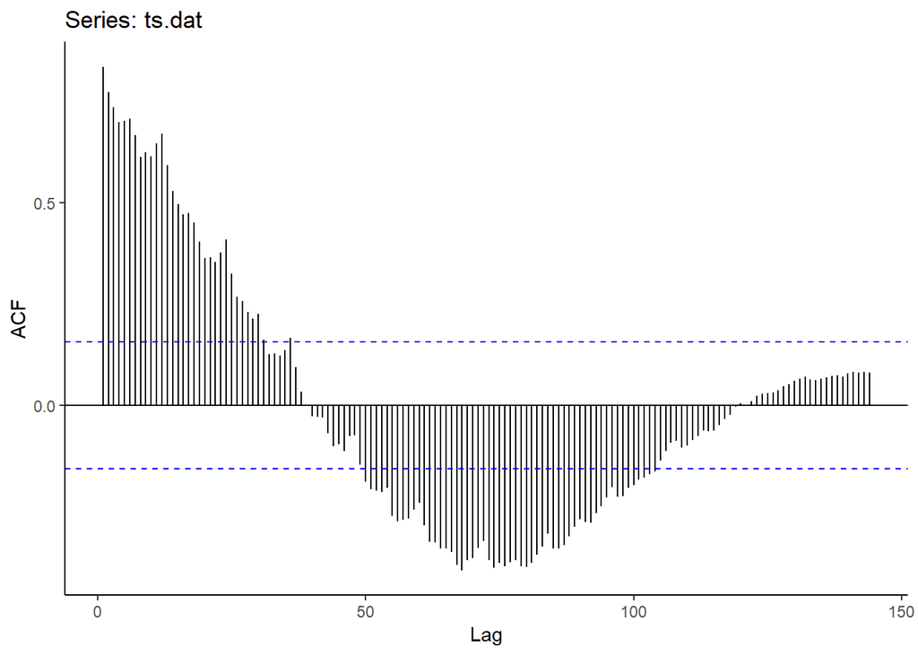

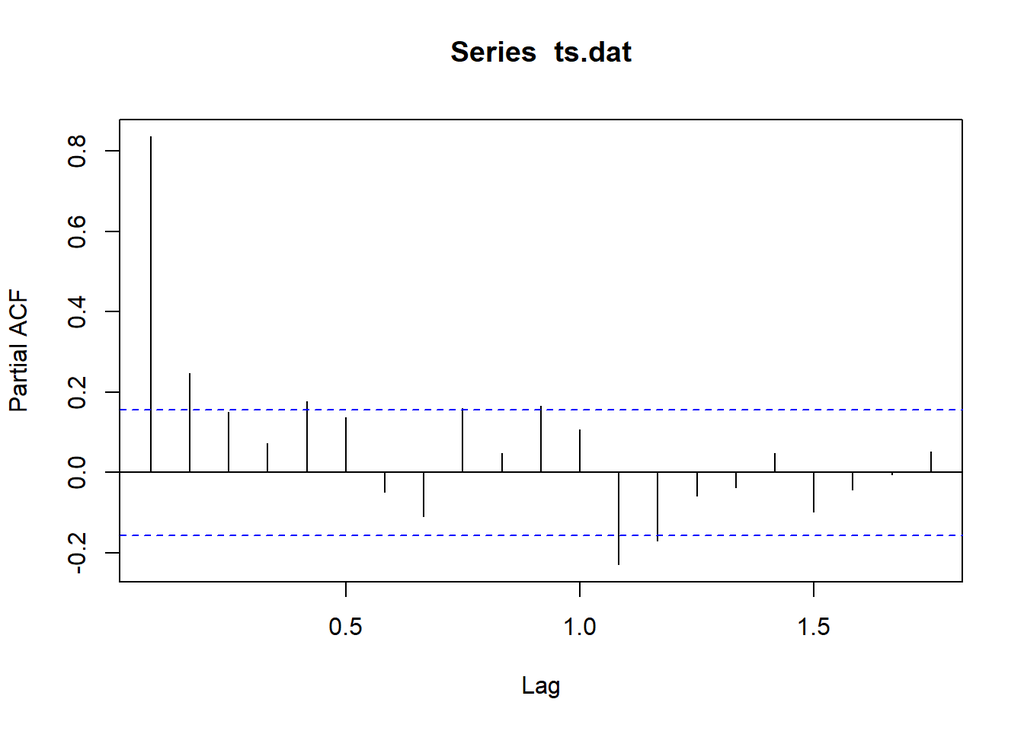

```
FALSE
FALSE   Box-Ljung test
FALSE
FALSE data:  ts.dat
FALSE X-squared = 3318.2, df = 144, p-value < 2.2e-16
```

```
FALSE
FALSE   Augmented Dickey-Fuller Test
FALSE
FALSE data:  ts.dat
FALSE Dickey-Fuller = -4.337, Lag order = 0, p-value = 0.01
FALSE alternative hypothesis: stationary
```

```
FALSE
FALSE   KPSS Test for Trend Stationarity
FALSE
FALSE data:  ts.dat
FALSE KPSS Trend = 0.68065, Truncation lag parameter = 4, p-value = 0.01
```

```
FALSE
FALSE   KPSS Test for Level Stationarity
FALSE
FALSE data:  ts.dat
FALSE KPSS Level = 1.4616, Truncation lag parameter = 4, p-value = 0.01
```

##### Additive vs.Multiplicative

The result says it is *multiplicative* model.

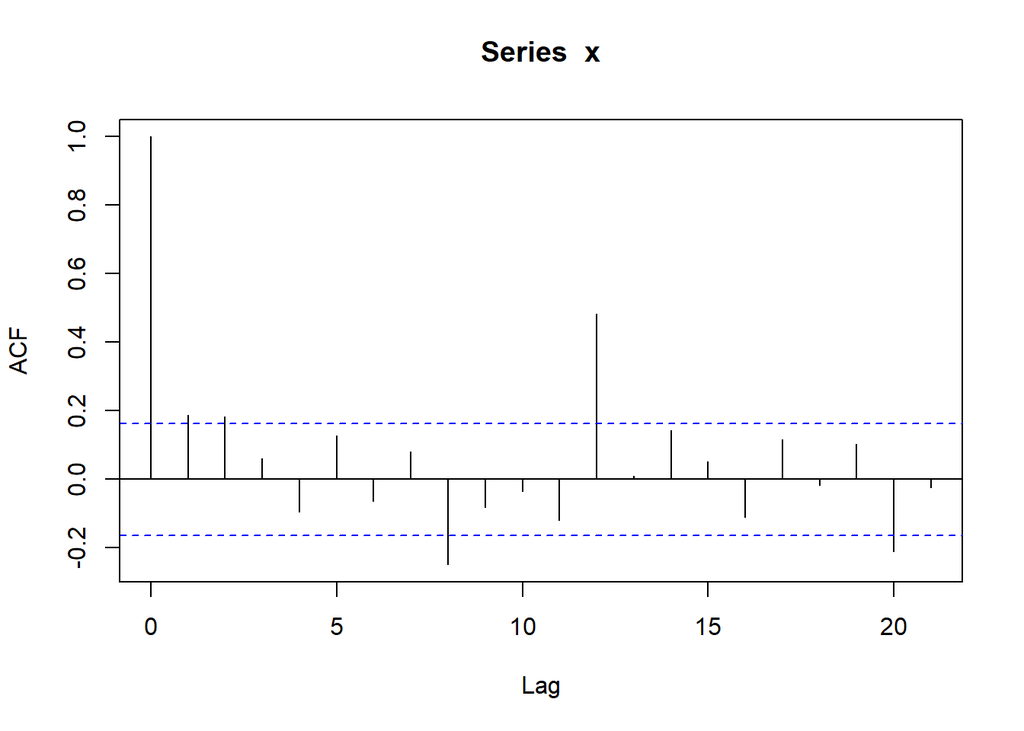

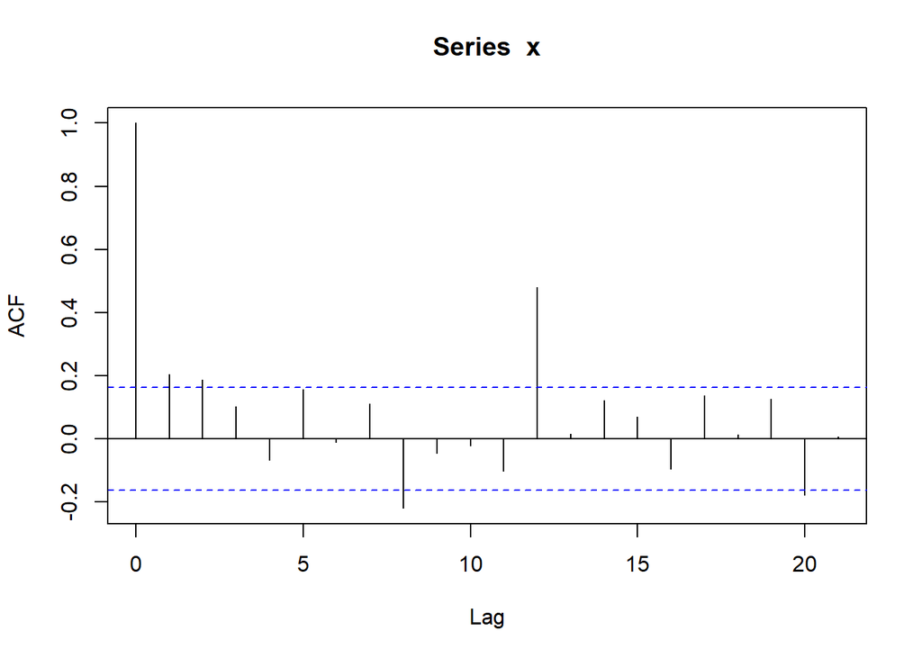

```
FALSE           ts_type
FALSE 1: Multiplicative
```

##### Models

```
FALSE [1] 108
```

```
FALSE [1] 48
```

```
FALSE                         ME      RMSE       MAE         MPE      MAPE     MASE
FALSE Training set  6.894562e-16  5.851318  4.673077   -8.404388  24.20025 1.025679
FALSE Test set     -1.097932e+01 11.780223 10.979322 -119.120799 119.12080 2.409818
FALSE                   ACF1 Theil's U
FALSE Training set 0.6461398        NA
FALSE Test set     0.8193088  5.405354
```

```
FALSE                       ME     RMSE      MAE       MPE     MAPE      MASE
FALSE Training set -0.05490004 4.621628 3.583446 -3.248599 17.51529 0.7865195
FALSE Test set      4.49220139 6.197420 4.763585 28.584154 33.66600 1.0455446
FALSE                    ACF1 Theil's U
FALSE Training set -0.3576170        NA
FALSE Test set      0.8193088  1.620428
```

```
FALSE                      ME      RMSE      MAE         MPE     MAPE     MASE
FALSE Training set  0.7644501  5.454814 4.556080   0.8382564 20.37295 1.000000
FALSE Test set     -8.6315622 10.160929 8.790532 -89.9218680 91.29253 1.929407
FALSE                   ACF1 Theil's U
FALSE Training set 0.5145345        NA
FALSE Test set     0.4086452  4.351039
```

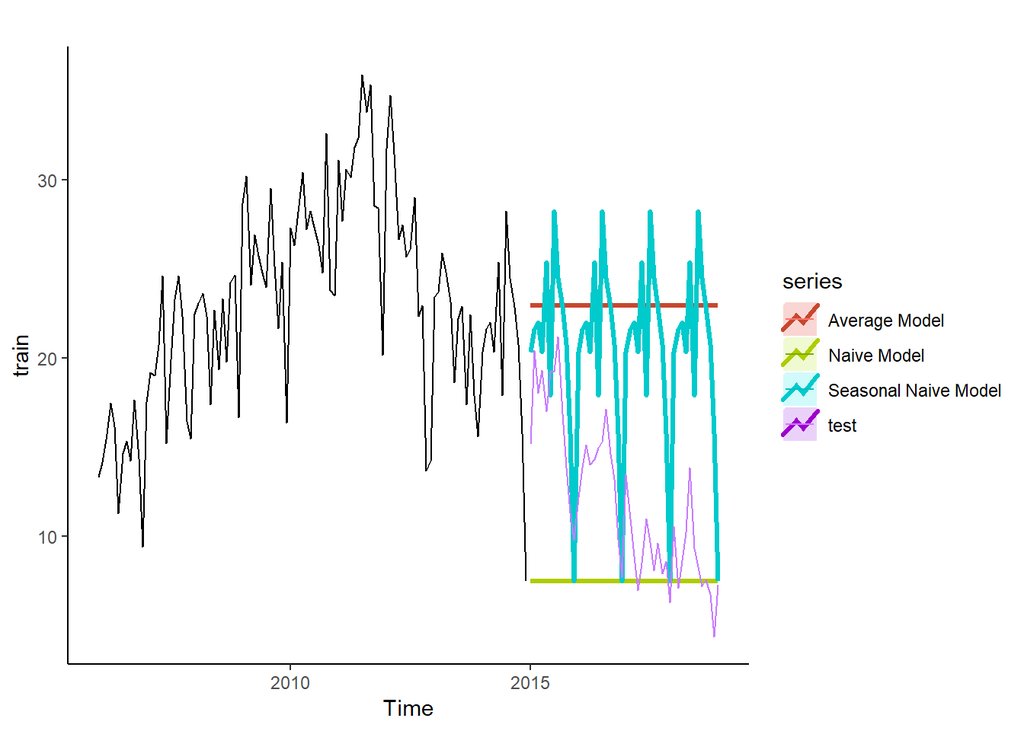

```
FALSE                         ME     RMSE      MAE      MPE     MAPE      MASE
FALSE Training set -1.161957e-15 4.621301 3.583959 -2.99072 17.49340 0.7866321
FALSE Test set      5.837252e+00 6.891858 5.859245 43.60097 44.10395 1.2860276
FALSE                    ACF1 Theil's U
FALSE Training set -0.3576170        NA
FALSE Test set      0.7684354  1.977951
```

```
FALSE                      ME     RMSE      MAE        MPE     MAPE      MASE
FALSE Training set -0.2728191 4.083304 3.233465  -5.245902 16.64397 0.7097034
FALSE Test set     -4.3997699 6.150654 5.299161 -56.399255 61.00296 1.1630965
FALSE                   ACF1 Theil's U
FALSE Training set 0.1109748        NA
FALSE Test set     0.8211833  2.966668
```

```
FALSE                     ME     RMSE      MAE       MPE     MAPE      MASE
FALSE Training set -0.285085 2.789163 2.129451  -3.15087 10.31493 0.4673866
FALSE Test set     -5.395353 6.634401 5.715367 -62.66821 64.26902 1.2544483
FALSE                      ACF1 Theil's U
FALSE Training set -0.008352425        NA
FALSE Test set      0.805870284  3.041418
```

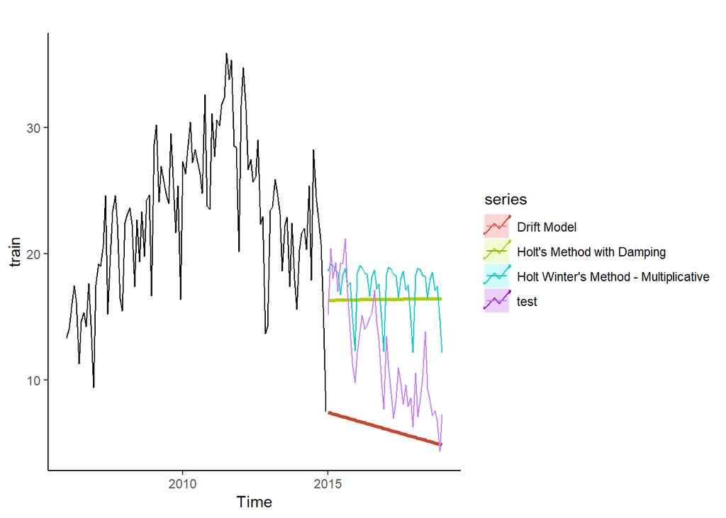

```
FALSE ETS(M,Ad,M)
FALSE
FALSE Call:
FALSE  ets(y = train, model = model.types[i])
FALSE
FALSE   Smoothing parameters:
FALSE     alpha = 0.3449
FALSE     beta  = 0.0042
FALSE     gamma = 2e-04
FALSE     phi   = 0.9756
FALSE
FALSE   Initial states:
FALSE     l = 12.2635
FALSE     b = 0.4778
FALSE     s = 0.6763 0.8785 1.0353 0.9867 1.0937 1.0529
FALSE            0.9501 1.0701 1.0689 1.0684 1.07 1.049
FALSE
FALSE   sigma:  0.1383
FALSE
FALSE      AIC     AICc      BIC
FALSE 768.7839 776.4693 817.0623
FALSE
FALSE Training set error measures:
FALSE                      ME     RMSE     MAE       MPE     MAPE      MASE
FALSE Training set -0.2924841 2.801256 2.15055 -2.895692 10.23482 0.4720175
FALSE                     ACF1
FALSE Training set -0.02553174
FALSE ETS(A,N,A)
FALSE
FALSE Call:
FALSE  ets(y = train, model = model.types[i])
FALSE
FALSE   Smoothing parameters:
FALSE     alpha = 0.4314
FALSE     gamma = 2e-04
FALSE
FALSE   Initial states:
FALSE     l = 17.0538
FALSE     s = -7.7423 -3.1752 0.5966 0.0543 2.3921 0.9692
FALSE            -0.6522 1.5254 1.9558 1.7447 1.7548 0.5768
```

[output cut: 74 more lines]

```
FALSE     l = 12.6057
FALSE     b = 1.0381
FALSE     s = 0.6808 0.8731 1.0429 0.9878 1.085 1.0414
FALSE            0.9514 1.0666 1.0767 1.0723 1.0802 1.0419
FALSE
FALSE   sigma:  0.1387
FALSE
FALSE      AIC     AICc      BIC
FALSE 769.8936 777.5790 818.1720
FALSE
FALSE Training set error measures:
FALSE                      ME     RMSE      MAE       MPE     MAPE      MASE
FALSE Training set -0.3322622 2.819486 2.156706 -3.129483 10.29787 0.4733687
FALSE                      ACF1
FALSE Training set -0.007011273
```

```
FALSE ETS(M,Md,M)
FALSE
FALSE Call:
FALSE  ets(y = train, model = "MMM")
FALSE
FALSE   Smoothing parameters:
FALSE     alpha = 0.3269
FALSE     beta  = 0.008
FALSE     gamma = 1e-04
FALSE     phi   = 0.964
FALSE
FALSE   Initial states:
FALSE     l = 12.6057
FALSE     b = 1.0381
FALSE     s = 0.6808 0.8731 1.0429 0.9878 1.085 1.0414
FALSE            0.9514 1.0666 1.0767 1.0723 1.0802 1.0419
FALSE
FALSE   sigma:  0.1387
FALSE
FALSE      AIC     AICc      BIC
FALSE 769.8936 777.5790 818.1720
FALSE
FALSE Training set error measures:
FALSE                      ME     RMSE      MAE       MPE     MAPE      MASE
FALSE Training set -0.3322622 2.819486 2.156706 -3.129483 10.29787 0.4733687
FALSE                      ACF1
FALSE Training set -0.007011273
```

```
FALSE ETS(A,N,A)
FALSE
FALSE Call:
FALSE  ets(y = train)
FALSE
FALSE   Smoothing parameters:
FALSE     alpha = 0.4314
FALSE     gamma = 2e-04
FALSE
FALSE   Initial states:
FALSE     l = 17.0538
FALSE     s = -7.7423 -3.1752 0.5966 0.0543 2.3921 0.9692
FALSE            -0.6522 1.5254 1.9558 1.7447 1.7548 0.5768
FALSE
FALSE   sigma:  3.0218
FALSE
FALSE      AIC     AICc      BIC
FALSE 759.5404 764.7578 799.7724
FALSE
FALSE Training set error measures:
FALSE                      ME     RMSE      MAE       MPE     MAPE      MASE
FALSE Training set 0.02490398 2.819152 2.203749 -1.345635 10.49735 0.4836941
FALSE                     ACF1
FALSE Training set -0.07352409
```

```
FALSE                      ME     RMSE      MAE        MPE     MAPE      MASE
FALSE Training set -0.3322622 2.819486 2.156706  -3.129483 10.29787 0.4733687
FALSE Test set     -4.0855237 5.386802 4.547006 -49.176390 51.50345 0.9980084
FALSE                      ACF1 Theil's U
FALSE Training set -0.007011273        NA
FALSE Test set      0.755834985  2.459622
```

```
FALSE                       ME     RMSE      MAE        MPE     MAPE      MASE
FALSE Training set  0.02490398 2.819152 2.203749  -1.345635 10.49735 0.4836941
FALSE Test set     -6.24149318 7.470189 6.357862 -69.911045 70.49846 1.3954676
FALSE                     ACF1 Theil's U
FALSE Training set -0.07352409        NA
FALSE Test set      0.74438971  3.357134
```

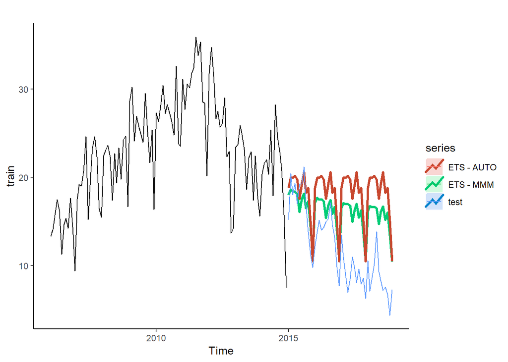

```
FALSE
FALSE   KPSS Test for Level Stationarity
FALSE
FALSE data:  train2
FALSE KPSS Level = 0.67446, Truncation lag parameter = 4, p-value = 0.01587
```

```
FALSE
FALSE   KPSS Test for Level Stationarity
FALSE
FALSE data:  train2_no_seasonality
FALSE KPSS Level = 1.2594, Truncation lag parameter = 3, p-value = 0.01
```

```
FALSE [1] 1
```

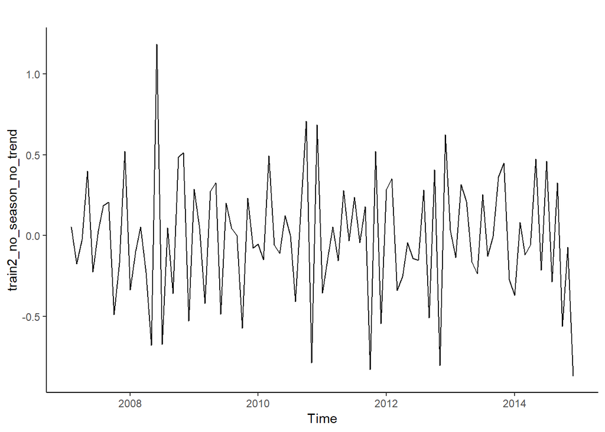

```
FALSE
FALSE   KPSS Test for Level Stationarity
FALSE
FALSE data:  train2_no_season_no_trend
FALSE KPSS Level = 0.061781, Truncation lag parameter = 3, p-value = 0.1
```

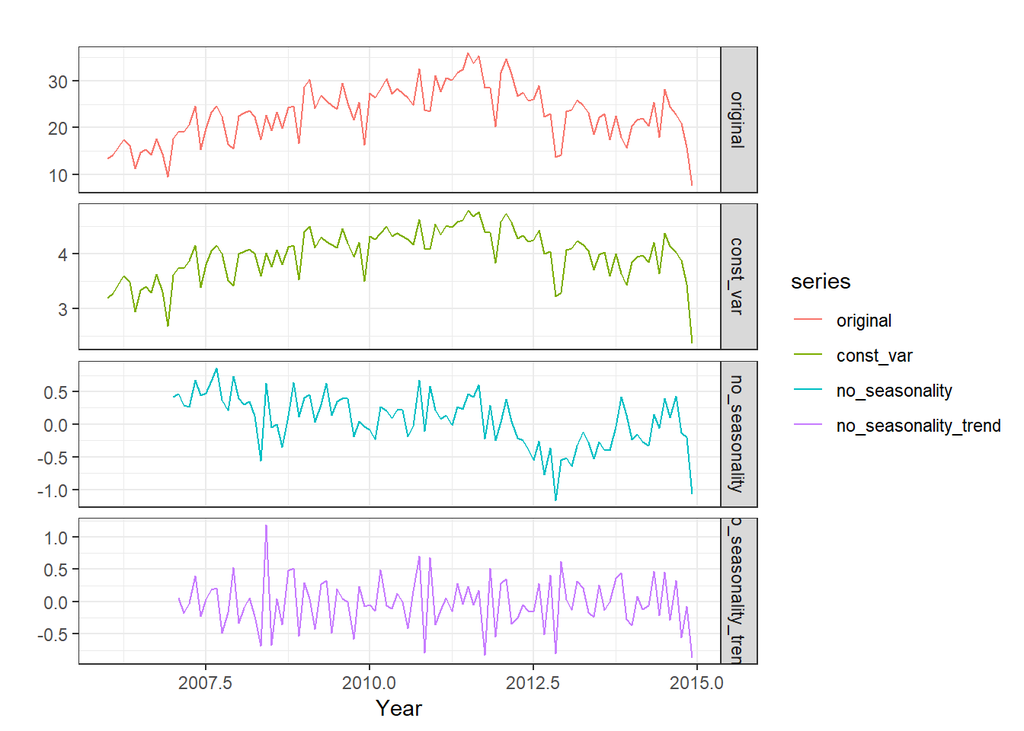

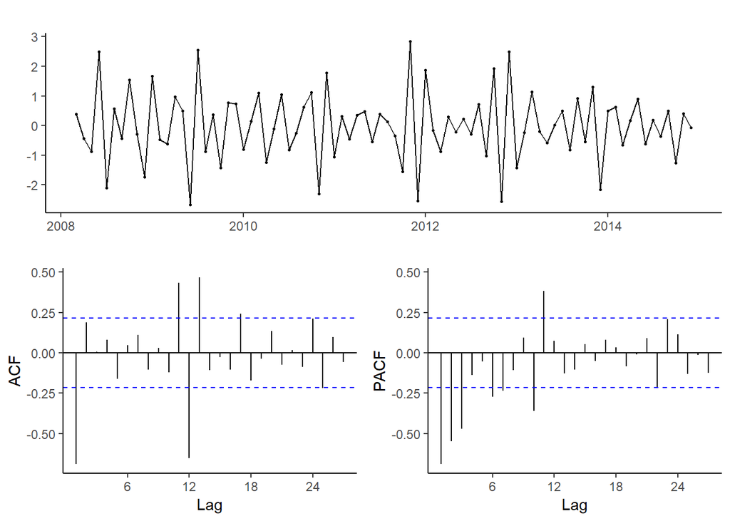

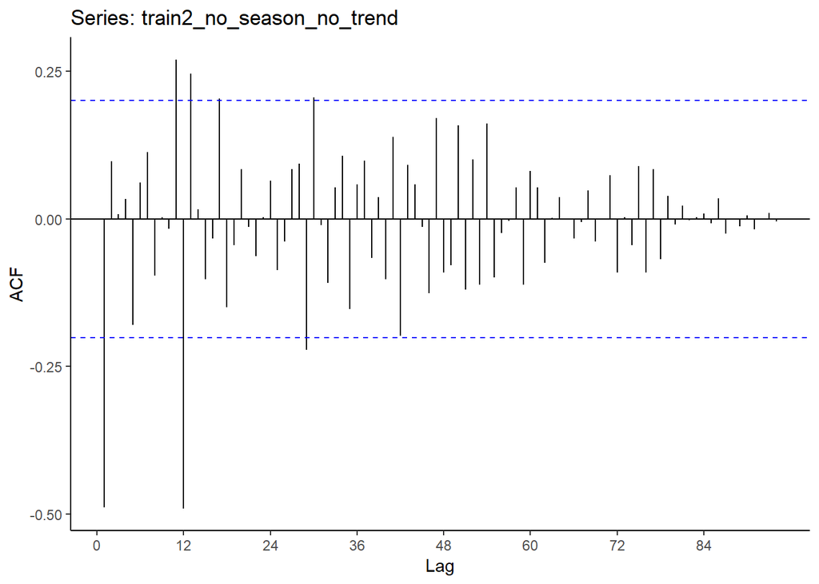

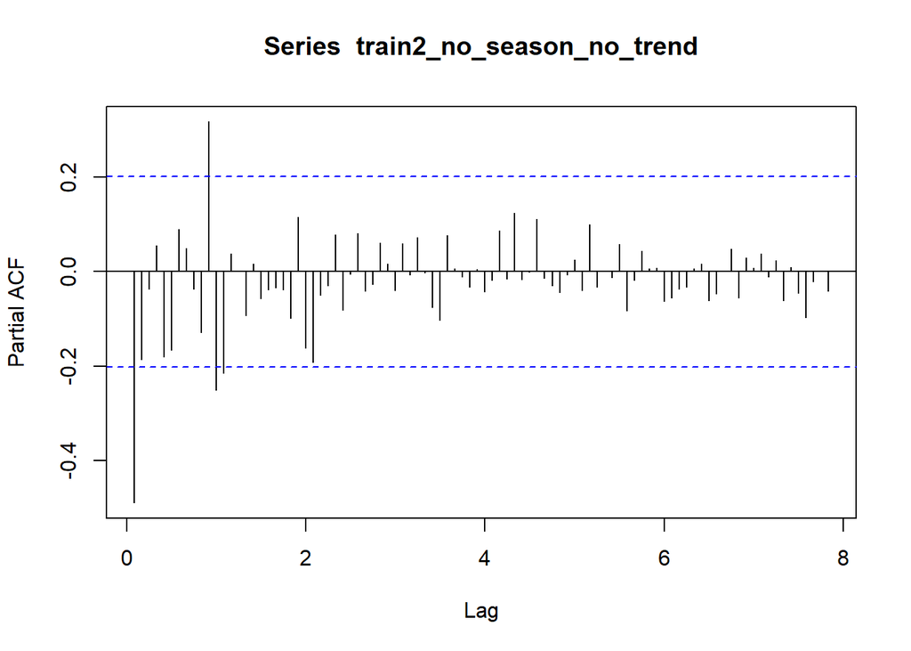

```
FALSE Series: train
FALSE ARIMA(0,1,2)(0,1,1)[12]
FALSE Box Cox transformation: lambda= 0.1554194
FALSE
FALSE Coefficients:
FALSE           ma1     ma2     sma1
FALSE       -0.6215  0.0621  -0.8041
FALSE s.e.   0.1136  0.1014   0.1629
FALSE
FALSE sigma^2 estimated as 0.06162:  log likelihood=-7.23
FALSE AIC=22.46   AICc=22.9   BIC=32.67
```

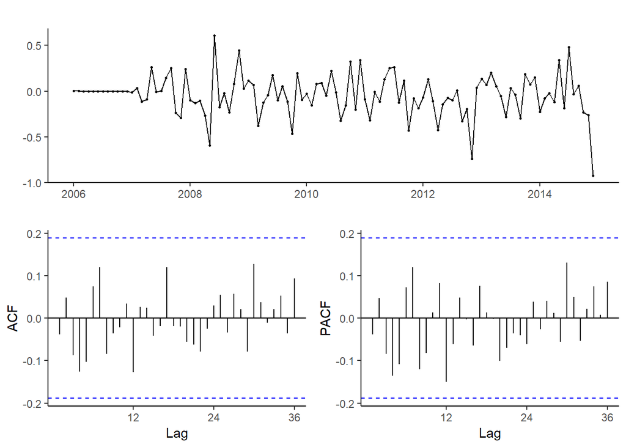

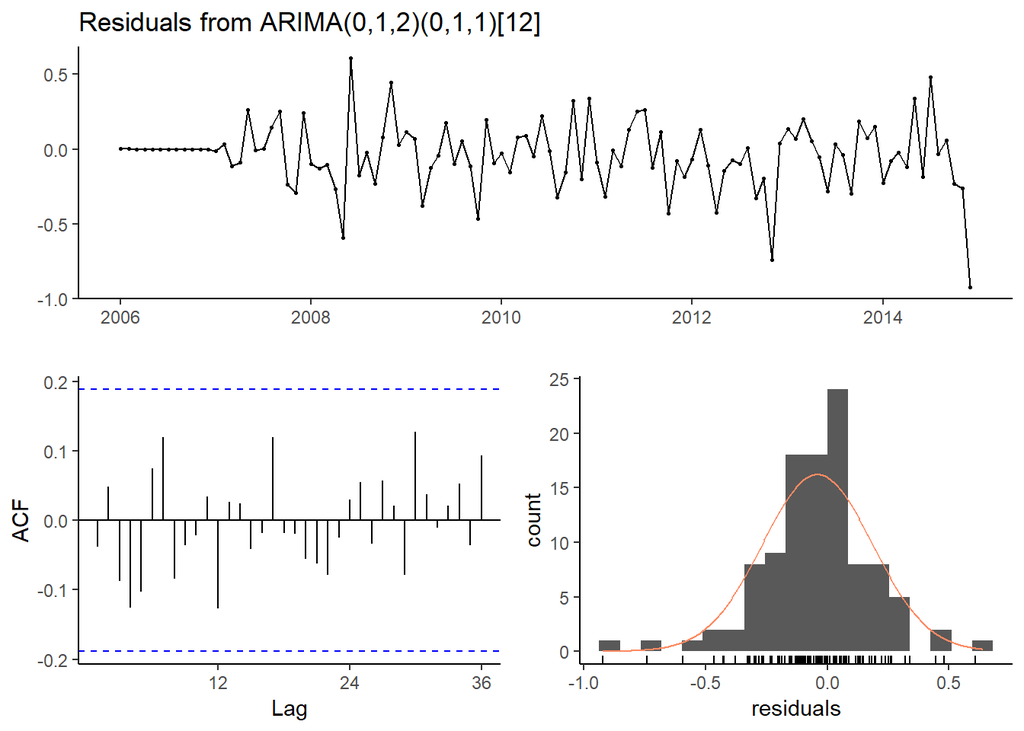

```
FALSE
FALSE   Ljung-Box test
FALSE
FALSE data:  Residuals from ARIMA(0,1,2)(0,1,1)[12]
FALSE Q* = 14.06, df = 19, p-value = 0.7802
FALSE
FALSE Model df: 3.   Total lags used: 22
```

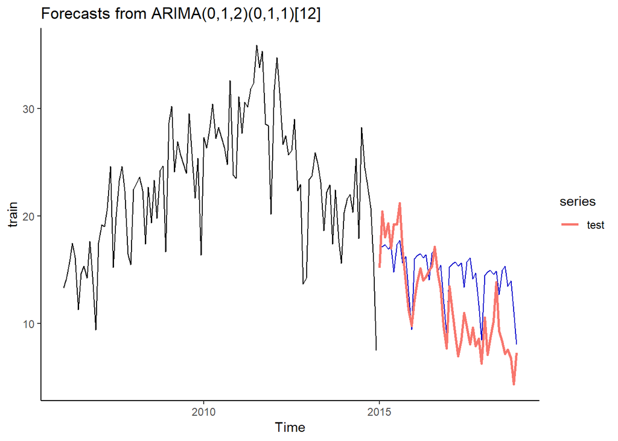

```
FALSE Series: train
FALSE ARIMA(0,1,1)(0,1,1)[12]
FALSE Box Cox transformation: lambda= 0.1554194
FALSE
FALSE Coefficients:
FALSE           ma1     sma1
FALSE       -0.5976  -0.7987
FALSE s.e.   0.0961   0.1596
FALSE
FALSE sigma^2 estimated as 0.06135:  log likelihood=-7.42
FALSE AIC=20.83   AICc=21.1   BIC=28.49
```

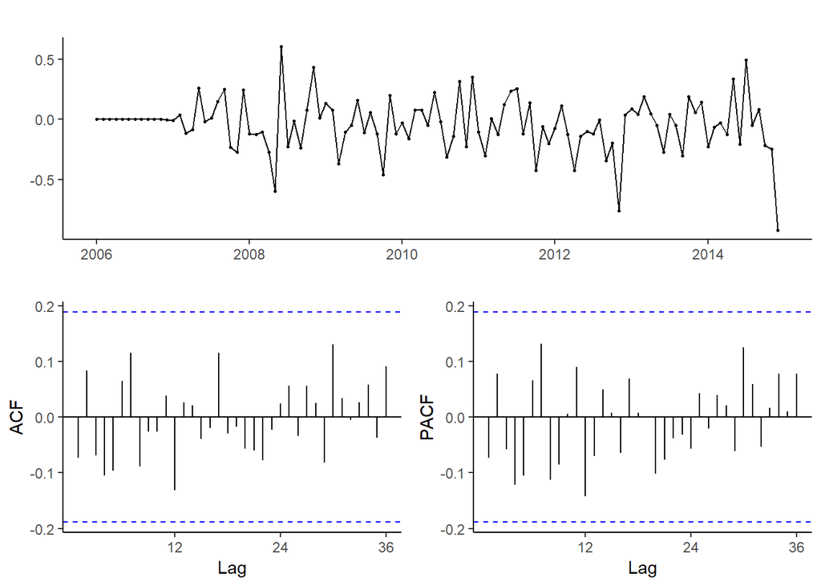

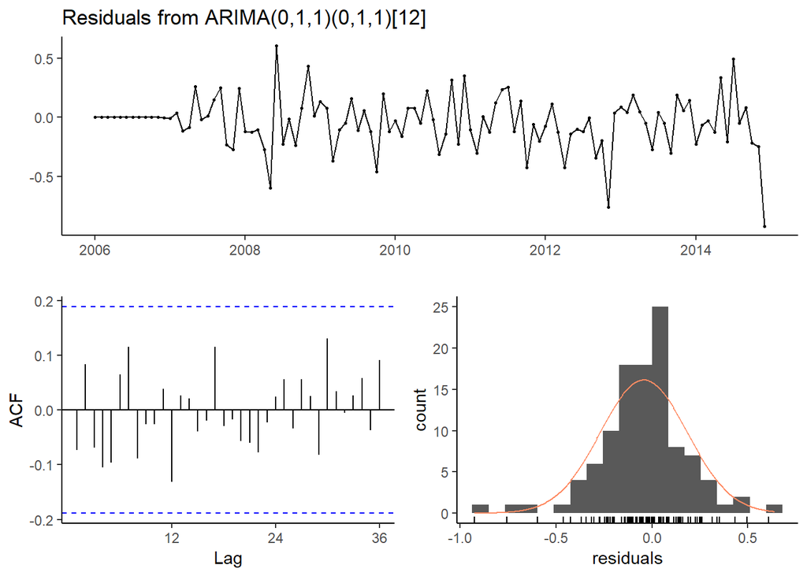

```
FALSE
FALSE   Ljung-Box test
FALSE
FALSE data:  Residuals from ARIMA(0,1,1)(0,1,1)[12]
FALSE Q* = 13.702, df = 20, p-value = 0.8453
FALSE
FALSE Model df: 2.   Total lags used: 22
```

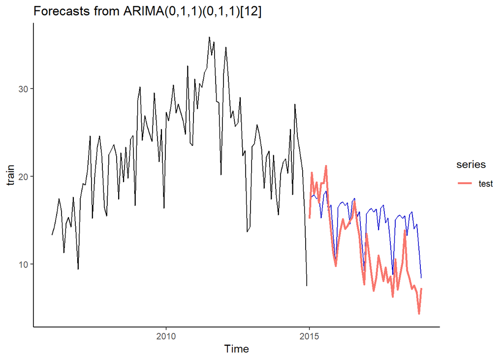

```
FALSE Series: train
FALSE ARIMA(0,1,1)(2,0,0)[12]
FALSE
FALSE Coefficients:
FALSE           ma1    sar1    sar2
FALSE       -0.6243  0.2846  0.3914
FALSE s.e.   0.0826  0.0867  0.0934
FALSE
FALSE sigma^2 estimated as 11.79:  log likelihood=-286
FALSE AIC=580   AICc=580.4   BIC=590.7
```

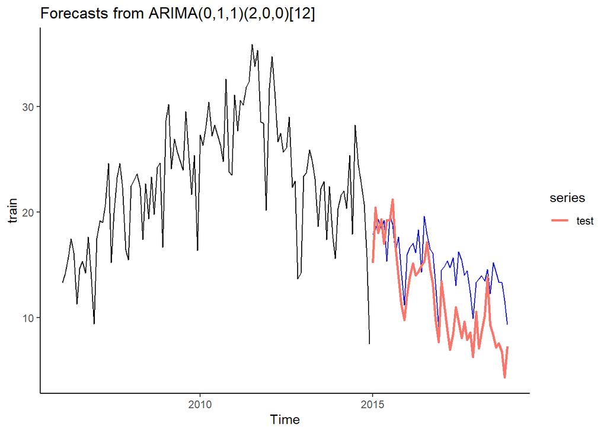

```
FALSE                      ME     RMSE      MAE        MPE     MAPE      MASE
FALSE Training set -0.5429128 3.124233 2.291173  -3.655736 10.42120 0.5028825
FALSE Test set     -2.7306607 4.297453 3.518083 -35.016815 39.17465 0.7721732
FALSE                     ACF1 Theil's U
FALSE Training set -0.03496994        NA
FALSE Test set      0.68675740  1.919243
```

```
FALSE                     ME     RMSE      MAE        MPE     MAPE      MASE
FALSE Training set -0.573058 3.130845 2.306648  -3.799531 10.49670 0.5062790
FALSE Test set     -3.260827 4.681190 3.848464 -40.073710 43.09066 0.8446874
FALSE                     ACF1 Theil's U
FALSE Training set -0.07222848        NA
FALSE Test set      0.68701153   2.10264
```

```
FALSE                       ME     RMSE      MAE        MPE     MAPE      MASE
FALSE Training set -0.07811794 3.368777 2.727772  -2.664438 13.28273 0.5987104
FALSE Test set     -3.16905152 4.217665 3.604197 -37.657441 39.90608 0.7910742
FALSE                     ACF1 Theil's U
FALSE Training set -0.02041126        NA
FALSE Test set      0.48671673  1.863199
```

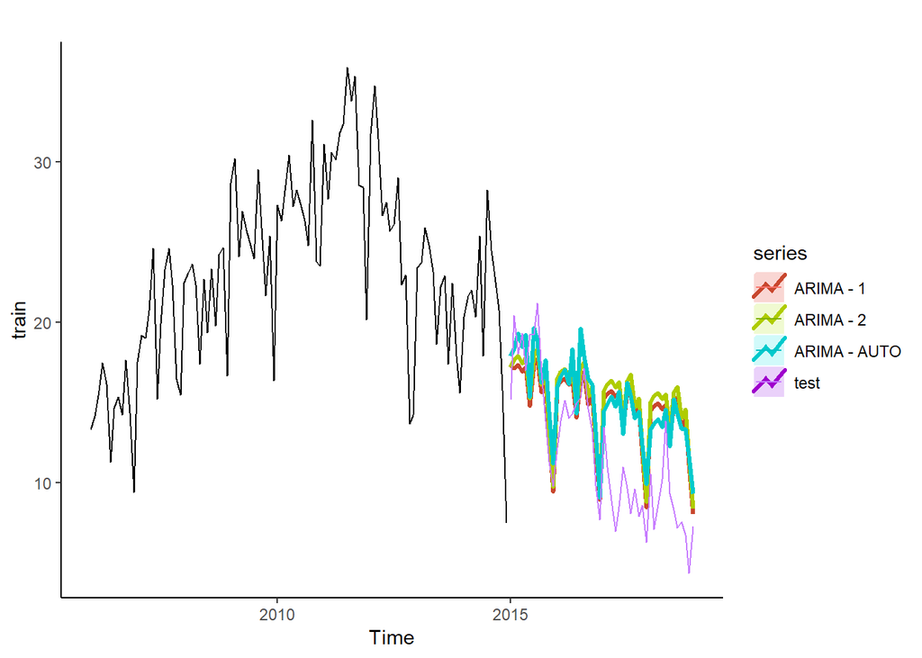

[output not shown]

[output cut: 1 more lines]

##### Answer

The analysis is based on the arrest rate based on *uniformed total population* across the year. As the above analysis shows, this tends to ignore the difference among the districts, race, age group, borough, crime types and such.

Incorporating the variables that could *explain the characteristics of each district* - race, age group, borough, and crime types - would be helpful. Still, this is *vulnerable to bias*.

As an evaluation, I would pay attention to *RMSE, ME, and MPE more* because large errors are undesirable in terms of forecasting, and ME and MPE allow for the bias check.